# chartmetric_analysis

---SQL---

Introduction This notebook provides SQL solutions for the take-home case study. Each SQL block is followed by an explanation to illustrate the business logic.

Q1: Retrieve artist names with total number of tracks (sorted descending)

SELECT ca.name AS artist_name, COUNT(DISTINCT l.cm_track) AS total_tracks FROM cm_artist ca JOIN l_cm_track_cm_artist l ON ca.id = l.cm_artist GROUP BY ca.name ORDER BY total_tracks DESC;

Explanation: Joins artist and linking table to count how many tracks each artist is associated with. Groups by artist name and sorts descending by total track count.

Q2: Retrieve artist names with total tracks and earliest album release year

SELECT ca.name AS artist_name, COUNT(DISTINCT l1.cm_track) AS total_tracks, MIN(EXTRACT(YEAR FROM a.release_date)) AS earliest_album_year FROM cm_artist ca JOIN l_cm_track_cm_artist l1 ON ca.id = l1.cm_artist JOIN l_cm_track_cm_album l2 ON l1.cm_track = l2.cm_track JOIN cm_album a ON l2.cm_album = a.id GROUP BY ca.name ORDER BY ca.name;

Explanation: Combines artist-track-album relationships. Retrieves both track count and earliest album release year for each artist.

Q3: Find track names associated with multiple artists

SELECT t.name AS track_name, STRING_AGG(DISTINCT a.name, ', ') AS artist_names FROM cm_track t JOIN l_cm_track_cm_artist l ON t.id = l.cm_track JOIN cm_artist a ON l.cm_artist = a.id GROUP BY t.name HAVING COUNT(DISTINCT a.id) > 1;

Explanation: Joins tracks and artists, groups by track name. Only returns tracks linked to more than one artist.

Bonus Q4: Average & Running Total of Follower Count per Artist

SELECT a.name AS artist_name, AVG(c.follower_count) OVER (PARTITION BY a.id) AS avg_follower_count, SUM(c.follower_count) OVER (PARTITION BY a.id ORDER BY c.created_at) AS running_total FROM cm_artist a JOIN cm_artist_cache_history c ON a.id = c.cm_artist;

Explanation: Uses window functions to calculate average follower count and running total for each artist. Assumes 'created_at' shows snapshot order for follower history.

---Python---

```python
import pandas as pd

# Load the dataset
df = pd.read_csv("/Users/mac/Desktop/Take_Home/Dataset.csv",dtype={'UPC': str},encoding='latin1')

print(df.head())
```

```
              UPC                                         ALBUM_NAME  \
0  00602527327341  Valentine's Day: Original Motion Picture Sound...
1  00602527327341  Valentine's Day: Original Motion Picture Sound...
2  00602527336381  Valentine's Day: Original Motion Picture Sound...
3  00794043918223  Valentine's Day: Original Motion Picture Sound...
4  00794043918261  Valentine's Day: Original Motion Picture Sound...

           ISRC TRACK_NAME        ARTIST_NAME       CM_ID  YOUTUBE_VIEWS  \
0  CA2HE0900200   Everyday  Sausalito Foxtrot  11140379.0        11561.0
1  CA2HE0900200   Everyday  Sausalito Foxtrot  11140379.0        11561.0
2  CA2HE0900200   Everyday  Sausalito Foxtrot  11140379.0        11561.0
3  CA2HE0900200   Everyday  Sausalito Foxtrot  11140379.0        11561.0
4  CA2HE0900200   Everyday  Sausalito Foxtrot  11140379.0        11561.0

   YOUTUBE_LIKES  YOUTUBE_COMMENTS  SOUNDCLOUD_PLAYS  ...  \
```

[output cut: 49 more lines]

```python
# Calculate the summary statistics (YOUTUBE_VIEWS)
summary_stats = df['YOUTUBE_VIEWS'].describe()
median = df['YOUTUBE_VIEWS'].median()

print("Summary Statistics:")
print(summary_stats)
print(f"Median: {median}")
```

```
Summary Statistics:
count    1.718400e+04
mean     1.435739e+07
std      5.668452e+07
min      1.000000e+01
25%      1.133630e+05
50%      7.382800e+05
75%      5.197632e+06
max      1.255992e+09
Name: YOUTUBE_VIEWS, dtype: float64
Median: 738280.0
```

```python
# Step 1: Select the required columns
selected_columns = ['CM_ID', 'SPOTIFY_PLAYS', 'SPOTIFY_POPULARITY',
                    'TIKTOK_TOP_VIDEOS_VIEWS', 'AIRPLAY_STREAMS']

#  a separate DataFrame
df_cleaned = df[selected_columns].copy()

# Step 2: Remove any duplicate rows
df_cleaned = df_cleaned.drop_duplicates()

# Step 3: Filter out rows where the SPOTIFY_POPULARITY is less than 10
df_cleaned = df_cleaned[df_cleaned['SPOTIFY_POPULARITY'] >= 10]

df_cleaned.to_csv("cleaned_chartmetric_data.csv", index=False)
df_cleaned.head()
```

|  | CM_ID | SPOTIFY_PLAYS | SPOTIFY_POPULARITY | TIKTOK_TOP_VIDEOS_VIEWS | AIRPLAY_STREAMS |
| --- | --- | --- | --- | --- | --- |
| 12 | 11209007.0 | 2250459.0 | 18.0 | 345.0 | 13.0 |
| 25 | 11209012.0 | 2008095.0 | 24.0 | 813.0 | 1.0 |
| 515 | 63948890.0 | 110971.0 | 19.0 | 838.0 | NaN |
| 516 | 63948905.0 | 86577.0 | 18.0 | 1837.0 | NaN |
| 517 | 63948891.0 | 88132.0 | 14.0 | NaN | NaN |

```python
# Delete the duplicate TRACK_NAME entries and retain only the one with the highest play count
df_filtered = df[['TRACK_NAME', 'SPOTIFY_PLAYS']].dropna()
df_filtered = df_filtered[df_filtered['SPOTIFY_PLAYS'] > 0]

#For the same TRACK_NAME, only the record with the largest SPOTIFY_PLAYS value should be retained
df_unique = df_filtered.sort_values('SPOTIFY_PLAYS', ascending=False).drop_duplicates(subset='TRACK_NAME', keep='first')

#  The top 5 tracks with the highest SPOTIFY_PLAYS
top_tracks = df_unique.head(5)
print(top_tracks)
```

```
                                        TRACK_NAME  SPOTIFY_PLAYS
9266                                   Meant To Be   1.281574e+09
36805  It's Beginning To Look A Lot Like Christmas   8.085047e+08
10952                                    Hurricane   5.966524e+08
28010                            Life Is A Highway   5.806962e+08
33099                              Die A Happy Man   5.642104e+08
```

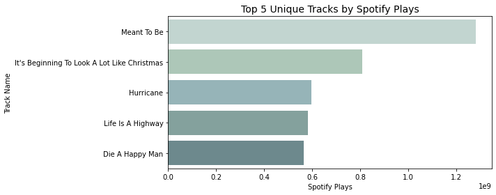

```python
import matplotlib.pyplot as plt
import seaborn as sns


morandi_palette = ['#bfd8d2', '#a9cbb7', '#91b8bd', '#7fa6a0', '#688d92']

plt.figure(figsize=(10, 4))
sns.barplot(
    data=top_tracks,
    x='SPOTIFY_PLAYS',
    y='TRACK_NAME',
    palette=morandi_palette
)

plt.title('Top 5 Unique Tracks by Spotify Plays', fontsize=14)
plt.xlabel('Spotify Plays')
plt.ylabel('Track Name')
plt.tight_layout()
plt.show()
```

```python
# Step 1: Extract the required columns and remove the missing values
df_streams = df[['TRACK_NAME', 'AIRPLAY_STREAMS', 'AIRPLAY_STREAMS_MONTHLY_DIFF_PER']].dropna()

# Step 2:Identify the song with the highest monthly growth percentage
top_increase = df_streams.sort_values(by='AIRPLAY_STREAMS_MONTHLY_DIFF_PER', ascending=False).drop_duplicates(subset='TRACK_NAME', keep='first').head(1)

print("The song that has seen the fastest growth in Airplay usage：")
print(top_increase)
```

```
The song that has seen the fastest growth in Airplay usage：
             TRACK_NAME  AIRPLAY_STREAMS  AIRPLAY_STREAMS_MONTHLY_DIFF_PER
10694  Remember Me Well             14.0                             600.0
```

```python
print(df.columns.tolist())
```

[output not shown]

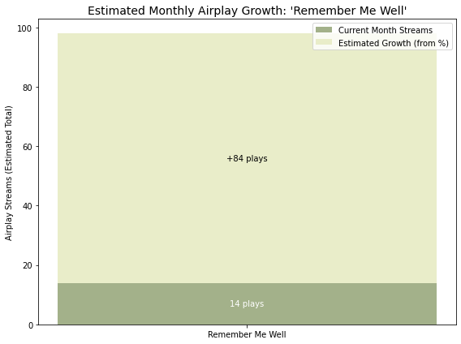

```python
import matplotlib.pyplot as plt

# Graph showing the maximum percentage increase obtained
cols = ['TRACK_NAME', 'AIRPLAY_STREAMS', 'AIRPLAY_STREAMS_MONTHLY_DIFF_PER']
df_air = df[cols].dropna()
top = df_air.sort_values(by='AIRPLAY_STREAMS_MONTHLY_DIFF_PER', ascending=False).drop_duplicates(subset='TRACK_NAME').head(1)

# extract values
track_name = top.iloc[0]['TRACK_NAME']
streams = top.iloc[0]['AIRPLAY_STREAMS']
growth_per = top.iloc[0]['AIRPLAY_STREAMS_MONTHLY_DIFF_PER']
growth_count = streams * growth_per / 100

# Visualization (Unified Unit Stacked Chart)
plt.figure(figsize=(8,6))
plt.bar(track_name, streams, color='#a3b18a', label='Current Month Streams')
plt.bar(track_name, growth_count, bottom=streams, color='#e9edc9', label='Estimated Growth (from %)')
plt.text(track_name, streams/2, f"{int(streams)} plays", ha='center', va='center', color='white')
plt.text(track_name, streams + growth_count/2, f"+{int(growth_count)} plays", ha='center', va='center', color='black')
plt.title(f"Estimated Monthly Airplay Growth: '{track_name}'", fontsize=14)
plt.ylabel("Airplay Streams (Estimated Total)")
plt.legend()
plt.tight_layout()
plt.show()
```

```python
print(top_increase[['TRACK_NAME', 'AIRPLAY_STREAMS', 'AIRPLAY_STREAMS_MONTHLY_DIFF_PER']])
```

```
             TRACK_NAME  AIRPLAY_STREAMS  AIRPLAY_STREAMS_MONTHLY_DIFF_PER
10694  Remember Me Well             14.0                             600.0
```

```python
# Step 1: Delete those without UPC codes
df = df.dropna(subset=['UPC'])
df['UPC'] = df['UPC'].astype(str)

# Step 2: Select all the columns related to playback volumes of all platforms
stream_columns = [
    'SPOTIFY_PLAYS',
    'YOUTUBE_VIEWS',
    'SOUNDCLOUD_PLAYS',
    'TIKTOK_TOP_VIDEOS_VIEWS',
    'AIRPLAY_STREAMS',
    'PANDORA_LIFETIME_STREAMS',
    'SIRIUSXM_STREAMS'
]

# Step 3: Replace the missing values with 0 (for ease of addition)
df[stream_columns] = df[stream_columns].fillna(0)

# Step 4: Calculate the total play count for each row (sum up the play counts of multiple songs)
df['TOTAL_STREAMS'] = df[stream_columns].sum(axis=1)

# Step 5: Aggregate the total play counts of each album
album_total = df.groupby('UPC')['TOTAL_STREAMS'].sum().reset_index()

# Step 6: Calculate the average play count of all albums
avg_total = album_total['TOTAL_STREAMS'].mean()

# Step 7: Calculate the difference for each album
album_total['DIFF_FROM_AVERAGE'] = album_total['TOTAL_STREAMS'] - avg_total

# Step 8: Merge album names
album_names = df[['UPC', 'ALBUM_NAME']].drop_duplicates()
album_total = album_total.merge(album_names, on='UPC', how='left')
album_total['UPC'] = album_total['UPC'].astype(str)

# Step 9: View the top 10 albums with the greatest differences in values
top_albums = album_total.sort_values(by='DIFF_FROM_AVERAGE', ascending=False).head(10)
print(top_albums)
```

```
                 UPC  TOTAL_STREAMS  DIFF_FROM_AVERAGE  \
8183  00843930096374   2.594424e+10       2.575781e+10
7440  00843930086658   1.942636e+10       1.923993e+10
8320  00843930098002   1.279298e+10       1.260654e+10
7332  00843930084968   1.197245e+10       1.178601e+10
7708  00843930089871   1.115474e+10       1.096831e+10
7783  00843930090723   1.088046e+10       1.069403e+10
4658  00843930044177   1.058293e+10       1.039649e+10
4659  00843930044184   1.058293e+10       1.039649e+10
6907  00843930079711   1.058032e+10       1.039388e+10
6845  00843930078967   1.057575e+10       1.038932e+10

                             ALBUM_NAME
8183             Best Of 2010's Country
7440                Country TikTok Hits
8320               Chill Summer Country
7332                      Greatest Hits
7708      New Year's Party Country 2023
7783  Best Country Valentine's Day 2023
4658                    Cottage Country
4659                     Summer Country
6907  Best Country Valentine's Day 2022
6845           New Year's Party Country
```

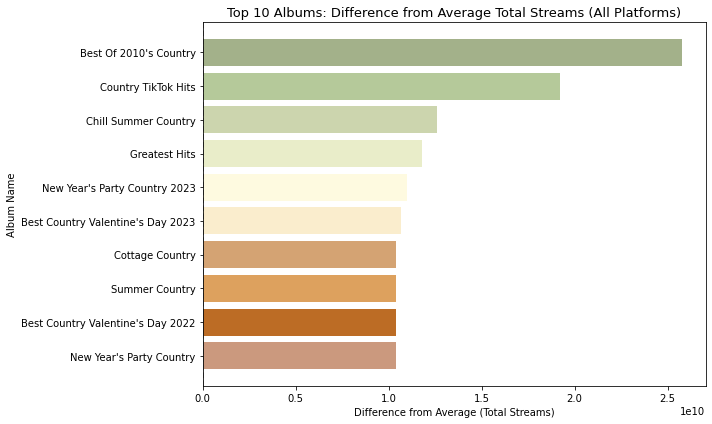

```python
morandi_colors = [
    '#a3b18a', '#b5c99a', '#ccd5ae', '#e9edc9', '#fefae0',
    '#faedcd', '#d4a373', '#dda15e', '#bc6c25', '#cb997e'
]

plt.figure(figsize=(10, 6))
bars = plt.barh(
    top_albums['ALBUM_NAME'],
    top_albums['DIFF_FROM_AVERAGE'],
    color=morandi_colors
)

plt.axvline(0, color='gray', linestyle='--')
plt.title("Top 10 Albums: Difference from Average Total Streams (All Platforms)", fontsize=13)
plt.xlabel("Difference from Average (Total Streams)")
plt.ylabel("Album Name")
plt.gca().invert_yaxis()
plt.tight_layout()
plt.show()
```

```python
# Group by UPC, calculate the average value of YOUTUBE_VIEWS for each album
album_avg_views = df.groupby('UPC')['YOUTUBE_VIEWS'].mean().reset_index()

# Merge album names
album_names = df[['UPC', 'ALBUM_NAME']].drop_duplicates()
album_avg_views = album_avg_views.merge(album_names, on='UPC', how='left')

# Show the top 10 items
album_avg_views = album_avg_views.sort_values(by='YOUTUBE_VIEWS', ascending=False)
print(album_avg_views.head(10))
```

```
                 UPC  YOUTUBE_VIEWS          ALBUM_NAME
58    00600753864579    453178927.0     Country Forever
3184  00843930024070    396980475.0            H.O.L.Y.
3185  00843930024087    396980475.0            H.O.L.Y.
3300  00843930025329    396980475.0            H.O.L.Y.
2159  00843930011186    391288077.0          Bottoms Up
541   00602537705733    391288077.0          Bottoms Up
540   00602537705719    391288077.0          Bottoms Up
2160  00843930011193    391288077.0          Bottoms Up
46    00600753374207    374409648.0         100 Country
8418  00887254467724    374409648.0  American Heartland
```

Raw Correlation Before Log Transformation

This scatter plot shows the correlation between YouTube views and Spotify plays in raw scale. The strong skewness and presence of outliers indicate that a transformation might be necessary. Keeping this version helps illustrate the importance of preprocessing and provides a clear contrast with the log-transformed analysis.

```
Filtered Pearson correlation: r = 0.7271, p-value = 0.0000e+00
```

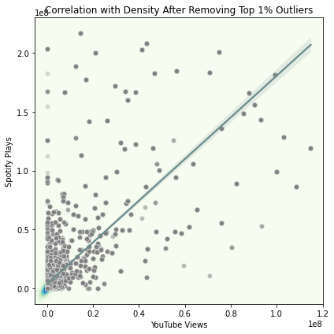

```python
import seaborn as sns
import matplotlib.pyplot as plt
from scipy.stats import pearsonr

# define data
df_corr = df[['YOUTUBE_VIEWS', 'SPOTIFY_PLAYS']].dropna()
q1 = df_corr['YOUTUBE_VIEWS'].quantile(0.99)
q2 = df_corr['SPOTIFY_PLAYS'].quantile(0.99)
df_filtered = df_corr[(df_corr['YOUTUBE_VIEWS'] <= q1) & (df_corr['SPOTIFY_PLAYS'] <= q2)]

# calculate the correlation coefficie
r, p = pearsonr(df_filtered['YOUTUBE_VIEWS'], df_filtered['SPOTIFY_PLAYS'])
print(f"Filtered Pearson correlation: r = {r:.4f}, p-value = {p:.4e}")

# Visualization (scatter plot + density plot)
plt.figure(figsize=(6,6))
sns.kdeplot(
    data=df_filtered,
    x='YOUTUBE_VIEWS',
    y='SPOTIFY_PLAYS',
    fill=True,
    thresh=0,
    levels=10,
    cmap="GnBu"
)
sns.scatterplot(
    data=df_filtered,
    x='YOUTUBE_VIEWS',
    y='SPOTIFY_PLAYS',
    color='gray',
    alpha=0.3
)
sns.regplot(
    data=df_filtered,
    x='YOUTUBE_VIEWS',
    y='SPOTIFY_PLAYS',
    scatter=False,
    line_kws={'color': '#6c8c8e'}
)
plt.title('Correlation with Density After Removing Top 1% Outliers', fontsize=12)
plt.xlabel('YouTube Views')
plt.ylabel('Spotify Plays')
plt.tight_layout()
plt.show()
```

Correlation Between YouTube Views and Spotify Plays

I analyzed the correlation between YouTube views and Spotify plays. After removing the top 1% outliers, the Pearson correlation was around 0.72, suggesting a strong linear relationship. However, the data was heavily skewed.

This transformation helps reveal a more reliable and interpretable relationship, especially across platforms with different usage scales.

```
Log-Transformed Pearson Correlation: r = 0.6979, p-value = 0.0000e+00
```

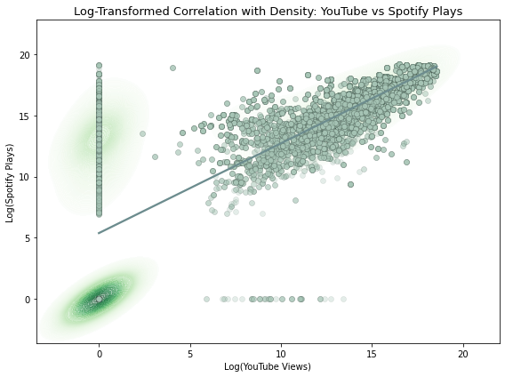

```python
import numpy as np

# 1. Log transform
df_log = df_filtered.copy()
df_log['LOG_YOUTUBE_VIEWS'] = np.log1p(df_log['YOUTUBE_VIEWS'])
df_log['LOG_SPOTIFY_PLAYS'] = np.log1p(df_log['SPOTIFY_PLAYS'])

# 2. Pearson correlation
r_log, p_log = pearsonr(df_log['LOG_YOUTUBE_VIEWS'], df_log['LOG_SPOTIFY_PLAYS'])
print(f"\nLog-Transformed Pearson Correlation: r = {r_log:.4f}, p-value = {p_log:.4e}")

# 3. Plot
plt.figure(figsize=(8, 6))

# Density shadow background
sns.kdeplot(
    data=df_log,
    x='LOG_YOUTUBE_VIEWS',
    y='LOG_SPOTIFY_PLAYS',
    fill=True,
    cmap='Greens',
    alpha=0.4,
    thresh=0.05,
    levels=100
)

# Scatter plot with aesthetic
sns.regplot(
    data=df_log,
    x='LOG_YOUTUBE_VIEWS',
    y='LOG_SPOTIFY_PLAYS',
    scatter_kws={
        'alpha': 0.3,
        'color': '#a8c6b7',
        'edgecolor': '#4a5c54',
        'linewidth': 0.3
    },
    line_kws={'color': '#6c8c8e'}
)

plt.title('Log-Transformed Correlation with Density: YouTube vs Spotify Plays', fontsize=13)
plt.xlabel('Log(YouTube Views)')
plt.ylabel('Log(Spotify Plays)')
plt.tight_layout()
plt.show()
```

```python
import pandas as pd
from sklearn.preprocessing import MinMaxScaler

# Step 1: Select the indicators to be used for scoring
weights = {
    # Market influence (35%)
    'YOUTUBE_VIEWS': 0.07,
    'SPOTIFY_PLAYS': 0.07,
    'TIKTOK_TOP_VIDEOS_VIEWS': 0.07,
    'GENIUS_PAGEVIEWS': 0.07,
    'SHAZAM_COUNT': 0.07,
    # Activity level (25%)
    'TIKTOK_POSTS_MONTHLY_DIFF_PER': 0.05,
    'SHAZAM_COUNT_MONTHLY_DIFF_PER': 0.05,
    'YOUTUBE_VIEWS_MONTHLY_DIFF_PER': 0.05,
    'SOUNDCLOUD_PLAYS_MONTHLY_DIFF_PER': 0.05,
    'SPOTIFY_PLAYS_MONTHLY_DIFF_PER': 0.05,
    # Business value (25%)
    'PANDORA_LIFETIME_STREAMS': 0.08,
    'AIRPLAY_STREAMS': 0.06,
    'SIRIUSXM_STREAMS': 0.06,
    'SOUNDCLOUD_PLAYS': 0.05,
    # Professional recognition (15%)
    'CM_TRACK_RANK': 0.08,
    'TIDAL_POPULARITY': 0.07
}

# Step 2: Read and aggregate data (aggregate average values by artist)

rank_df = df.groupby('ARTIST_NAME')[list(weights.keys())].mean().reset_index()

# Step 3: normalization
scaler = MinMaxScaler()
scaled_values = scaler.fit_transform(rank_df.drop(columns=['ARTIST_NAME']))
scaled_df = pd.DataFrame(scaled_values, columns=rank_df.columns[1:])
scaled_df['ARTIST_NAME'] = rank_df['ARTIST_NAME'].values

# Step 4: Calculate the total score (sum up according to the weighted formula)
scaled_df['total_score'] = sum(scaled_df[k] * w for k, w in weights.items())

# Step 5: Ranking by quantile classification
quantiles = scaled_df['total_score'].quantile([0.95, 0.85, 0.65])

def assign_rank(score):
    if score >= quantiles[0.95]:
        return 'S'
    elif score >= quantiles[0.85]:
        return 'A'
    elif score >= quantiles[0.65]:
        return 'B'
    else:
        return 'C'

scaled_df['RANK'] = scaled_df['total_score'].apply(assign_rank)

# Step 6: Map the order of the levels and sort them, retaining the final result
rank_order = {'S': 1, 'A': 2, 'B': 3, 'C': 4}
scaled_df['rank_order'] = scaled_df['RANK'].map(rank_order)
final_df = scaled_df[['ARTIST_NAME', 'RANK', 'total_score', 'rank_order']].sort_values(
    by=['rank_order', 'total_score'], ascending=[True, False]
).drop(columns=['rank_order','total_score'])

# Step 7: Output the top 10 entries
print(final_df.head(10))
```

```
                  ARTIST_NAME RANK
232                Luke Combs    S
153        Hitkidd & GloRilla    S
63   Carly Pearce & Lee Brice    A
355            The Band Perry    A
400           Various Artists    A
297               Riley Green    A
51                Brett Young    B
127      Florida Georgia Line    B
343                 Sugarland    B
372              Thomas Rhett    B
```

Artist Performance Scoring System Overview

This scoring system evaluates artists based on their aggregated performance across major music platforms. It is designed to be multi-dimensional, weighted, explainable, and easily adjustable.

1. Dimensions & Metric Selection

This scoring system is suitable for:

- Internal resource allocation (e.g., promotional priorities)
- Talent scouting and partnership evaluation
- Executive dashboards and performance tracking (e.g., in Looker or Tableau)

The model is flexible and adaptable—weights and dimensions can be fine-tuned based on business goals or data insights.

```python
df_viz = df[['TRACK_NAME', 'ARTIST_NAME',
             'SPOTIFY_PLAYS',
             'TIKTOK_TOP_VIDEOS_VIEWS',
             'SHAZAM_COUNT',
             'AIRPLAY_STREAMS',
             'YOUTUBE_VIEWS']]

# Add log transformation (to make it easier to observe the differences among small-scale items)
df_viz['log_SPOTIFY'] = np.log1p(df_viz['SPOTIFY_PLAYS'])
df_viz['log_TIKTOK'] = np.log1p(df_viz['TIKTOK_TOP_VIDEOS_VIEWS'])
df_viz['log_SHAZAM'] = np.log1p(df_viz['SHAZAM_COUNT'])
df_viz['log_AIRPLAY'] = np.log1p(df_viz['AIRPLAY_STREAMS'])
df_viz['log_YOUTUBE'] = np.log1p(df_viz['YOUTUBE_VIEWS'])

# Export to CSV
df_viz.to_csv('track_platform_metrics.csv', index=False)
```